# Media Matters: Text-Based Analysis of How The Guardian and The New York Times Cover US News

Mohan Krishna Askani and Naveen Korrapati

#### Instructor: Stevenson Bolivar Atuesta

May 6, 2025

# Objective

Our project aims to compare topic emphasis between two prominent publishers: **The New York Times**, a leading U.S.based outlet, and **The Guardian**, a UK-based publication with a dedicated **U.S. news section** by examining the thematic focus, sentiment patterns, and geographic distribution of coverage in their national news articles related to the United States using topic modeling, TF-IDF (Term-Frequency Inverse-Document Frequency), sentiment analysis, and location-based insights based on the data for April 2025.

This analysis is valuable because it highlights how two influential but geographically and editorially distinct publishers **The New York Times (U.S.)** and **The Guardian (UK)** cover news related to the United States. Even when reporting on similar national topics, outlets may diverge in story selection, linguistic framing, and emphasis, shaped by their editorial mission, cultural context, or intended readership. By analyzing such differences, we can gain insights into not just what is reported, but how and why it is framed in particular ways. This work may benefit:

- **Media Analysts & Journalists**: To examine how transatlantic outlets differ in their editorial tone, topical focus, and choice of language when covering U.S. issues.
- **News Consumers**: To enhance media literacy by showing how coverage can subtly vary depending on the outlet, encouraging critical engagement with diverse sources.
- **Data Scientists & NLP Researchers**: To support modeling efforts that detect bias, framing, or discourse patterns in real-world journalism. It also offers a practical use case for TF-IDF and other text processing techniques across media domains.

# Data Extraction and Cleaning

**The Guardian:**  
The data from The Guardian came through their API, which made things a little easier. It gave us the full article body, but it was still wrapped in HTML tags. So we had to clean that up by removing all the tags, links, numbers, punctuation, etc.,. One small issue was that some sentences still had odd punctuation or repeated breaks, so we had to fix spacing and make sure the text looked like normal paragraphs. Also, words like “Trump’s” or “don’t” showed up as “trumps” or “dont” after cleaning, so we created a custom function to cut off possessive endings and just keep the actual word.

```r
# loading required libraries
library(rvest)
library(readr)
library(tidyverse)
library(httr)
```

```r
# The Guardian API Key
gaurdian_api_key <- Sys.getenv("Gaurdian_API_Key")

# Function to pull The Guardian articles for a section/date range
get_gaurdian_articles <- function(section = "us-news",
                                  from = floor_date(Sys.Date() - months(1), unit = "month"),
                                  to = ceiling_date(Sys.Date() - months(1), unit = "month") - days(1),
                                  pages = 2) {
  all_articles <- list()
  for (i in 1:pages) {
    res <- GET("https://content.guardianapis.com/search", query = list(
      section = section,
      "from-date" = format(from, "%Y-%m-%d"),
      "to-date" = format(to, "%Y-%m-%d"),
      "show-fields" = "headline,trailText,body",
      "page-size" = 150,
      "page" = i,
      "api-key" = gaurdian_api_key
    ))

    content_json <- fromJSON(content(res, "text"), flatten = TRUE)
    articles <- content_json$response$results

    if (length(articles) == 0) break  # Stop if empty

    df <- tibble(
      title = articles$fields.headline,
      summary = articles$fields.trailText,
      body = articles$fields.body,
      date = as.Date(articles$webPublicationDate),
      url = articles$webUrl,
      section = articles$sectionName
    )

    all_articles[[i]] <- df
  }

  bind_rows(all_articles)
}

# Pulling the News Articles Data
guardian_news <- get_gaurdian_articles(section = "us-news", pages = 100)
```

```r
# Saving the File
# write.csv(as.data.frame(gaurdian_news) , file = "gaurdian_news_v2.csv", row.names = FALSE, quote = TRUE)
guardian_news <- read_csv("guardian_news_v2.csv")

# Custom cleaning function
text_clean_function_guardian <- function(raw_text) {
  cleaned_text <- read_html(raw_text) %>%
    html_text2() %>% # Extract clean text (preserves paragraph breaks)
    str_to_lower() %>% # converts word to lower case
    str_replace_all("\\b(\\w+)(['’]s)\\b", "\\1") %>% # Handling Possessive forms (Car's, Trump's etc.,)
    str_squish() %>% # Remove excessive white space

    # Remove numbers (standalone or within words like "covid19")
    str_replace_all("\\b\\w*\\d+\\w*\\b", "") %>%

    str_replace_all("[[:punct:]]", " ") %>% # Removing Punctuation
    str_squish() # Remove excessive white space

  return(cleaned_text)
}

guardian_news <- guardian_news %>% mutate(cleaned_body = map_chr(body, text_clean_function_guardian))

print(guardian_news$body[2])
```

```
## [1] "<p>There were navy blue and red baseball caps up and down the table, strategically placed in front of every cabinet member, and each bearing the message “Gulf of America”.</p> <p>Yet the unorthodox collection of headwear, embroidered with Donald Trump’s forced new name for the centuries-old …
```

```r
print(guardian_news$cleaned_body[2])
```

```
## [1] "there were navy blue and red baseball caps up and down the table strategically placed in front of every cabinet member and each bearing the message gulf of america yet the unorthodox collection of headwear embroidered with donald trump forced new name for the centuries old gulf of mexico was…
```

```r
# Calling New York Times API through curl
system('curl -s -o nyt-2025-4.json "https://api.nytimes.com/svc/archive/v1/2025/4.json?api-key=3MBRKQHHWDYuuAeX9QpkVd95XlrPBjCR"')

# Adjust path as needed
json_data <- fromJSON("nyt-2025-4.json", flatten = TRUE)

# Extract articles
docs <- json_data$response$docs

# Extract only US section News
us_news <- docs %>% filter(section_name %in% c('U.S.') & type_of_material == 'News')

# Extract body function from page URLs
body_extraction <- function(url) {
  page <- read_html(url)
  paragraphs <- page %>% html_elements("p") %>% html_text2()
  clean_text <- paste(paragraphs, collapse = " ")
  return(clean_text)
}

# Call body extract function and store output in full_body (stored only those with atleast 300 characters)
us_news <- us_news %>% mutate(raw_body = map_chr(web_url, body_extraction)) %>% filter(nchar(raw_body) >= 300)

# Full body cleaning function starts
clean_full_body <- function(text) {
  if (is.null(text) || is.na(text) || !is.character(text)) return("")
  cleaned <- text %>%
    gsub("(?:'|’)[sS]\\b", "", .) %>%
    # Remove the specific problematic sentence (all variations)
    gsub("We are having trouble retrieving the article content\\..*?(Log in\\.|Subscribe\\.|Advertisement)", "", ., perl = TRUE) %>%
    # Your existing cleaning steps
    gsub("(?i)Advertisement", "", .) %>%
    gsub("(?i)Please enable JavaScript in your browser settings", "", .) %>%
    gsub("(?i)while we verify access", "", .) %>%
    gsub("(?i)please exit and log into your Times account, or subscribe for all of The Times\\.", "", .) %>%
    gsub("(?i)Supported by", "", .) %>%
    gsub("(?i)Thank you for your patience.*?(Advertisement)?", "", ., perl = TRUE) %>%
    gsub("(?i)If you are in Reader mode.*?(Advertisement)?", "", ., perl = TRUE) %>%
    gsub("(?i)Already a subscriber\\? Log in\\.", "", .) %>%
    gsub("(?i)Want all of The Times\\? Subscribe\\.", "", .) %>%
    gsub("(?i)^By [A-Z][a-z]+ [A-Z][a-z]+( and [A-Z][a-z]+ [A-Z][a-z]+)?", "", .) %>%
    gsub("(?i)[A-Z][a-z]+ [A-Z][a-z]+ (reported from|covers|writes).*?\\.", "", .) %>%
    gsub("\\[.*?\\]", "", .) %>%
    gsub("[^A-Za-z .,!?]", " ", .) %>%
    gsub("\n", " ", .)
  return(cleaned)
}

# Call clean full body function and store output in cleaned_body
us_news <- us_news %>% mutate(cleaned_body = map_chr(raw_body, clean_full_body))
```

```r
# Saving the File
# write.csv(as.data.frame(us_news) , file = "newyorktimes_news_v1.csv", row.names = FALSE, quote = TRUE)
nyt_news <- read_csv("newyorktimes_news_v1.csv")

print(nyt_news$raw_body[1]) # sample raw body of the article
```

```
## [1] "Trump Administration Advertisement Supported by The lawsuit accuses President Trump of vastly overstepping his authority to “upturn the electoral playing field in his favor and against his political rivals.” By Nick Corasaniti Nearly every arm of the Democratic Party united in filing a lawsu…
```

```r
print(nyt_news$cleaned_body[1]) # sample cleaned body of the article
```

```
## [1] "trump administration lawsuit accuses president trump vastly overstepping authority upturn electoral playing field favor political rivals nick corasaniti nearly every arm democratic party united filing lawsuit trump administration monday night arguing recent executive order signed president s…
```

# Data Structuring

Both datasets are ultimately standardized into a common schema containing publisher name, published date, and cleaned article body to enable a balanced and comparable analysis of news coverage across the two sources.

```r
# loading required libraries
library(dplyr)
library(tidytext)
library(textstem)
library(ggplot2)
library(stringr)
library(tidyr)

guardian_news <- guardian_news %>% mutate(publisher = "The Guardian") %>% rename(pub_date = date)

# merging both the datasets
combined_news <- bind_rows(
  guardian_news %>% select(publisher, pub_date, cleaned_body),
  nyt_news %>% select(publisher, pub_date, cleaned_body)
)
```

# Analysis & Insights

As outlined in the objective, our analysis focused on comparing recent U.S. news coverage from The New York Times and The Guardian. We explored differences in their reporting through multiple lenses, including vocabulary, sentiment, and geographic focus.

## Topic Coverage

To examine how each publisher emphasizes different themes, we performed topic analysis using three complementary approaches:

- Top Unigrams: The most frequent individual words used in each publisher’s articles
- Top Bigrams: The most common two-word phrases to capture recurring themes
- TF-IDF: To identify words that are uniquely important to one publisher relative to the other

These methods together helped us highlight both shared and distinctive topics in their national news reporting.

### Top Unigrams

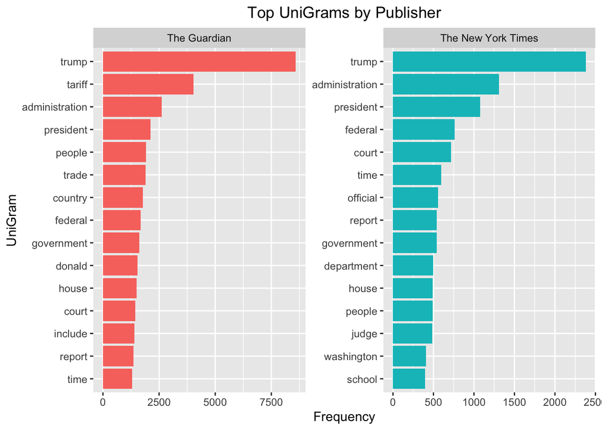

```r
# Tokenization and Normalization (unigrams)
tokenisation_standardisation_unigrams <- function(df){
  df <- df %>%
    unnest_tokens(word, cleaned_body) %>% # Tokenization of the cleaned text of body
    filter(str_length(word) >= 4) %>% # Removing words with length < 4
    anti_join(stop_words, by = "word") %>% # Handling stopwords
    filter(str_detect(word, "^[a-z]+$")) %>%  # considering only alphabets
    mutate(lemma = lemmatize_words(word)) # Reducing the words to its base form
}

# Tokenization and Standardisation of the words (unigrams)
guardian_data_tokenized_unigrams <- tokenisation_standardisation_unigrams(combined_news)

# Topic Coverage Analysis based on Uni-grams
top_unigrams <- guardian_data_tokenized_unigrams %>%
  count(publisher, lemma, sort = TRUE) %>%
  group_by(publisher) %>%
  slice_max(n, n = 15) %>%
  ungroup()

top_unigrams %>%
  ggplot(aes(x = reorder_within(lemma, n, publisher), y = n, fill = publisher)) +
  geom_col(show.legend = FALSE) +
  facet_wrap(~publisher, scales = "free") +
  scale_x_reordered() +
  coord_flip() +
  labs(title = "Top UniGrams by Publisher",
       x = "UniGram", y = "Frequency") +
  theme(
    plot.title = element_text(hjust = 0.5)
  )
```

The unigram comparison shows that both publishers heavily feature terms like “Trump”, “administration”, and “president”, indicating overlapping political focus. However, The Guardian emphasizes trade-related terms like “tariff” and “trade”, while The New York Times features more institutional terms like “court”, “department”, and “judge”, hinting at a stronger legal or bureaucratic framing.

### Top Bigrams

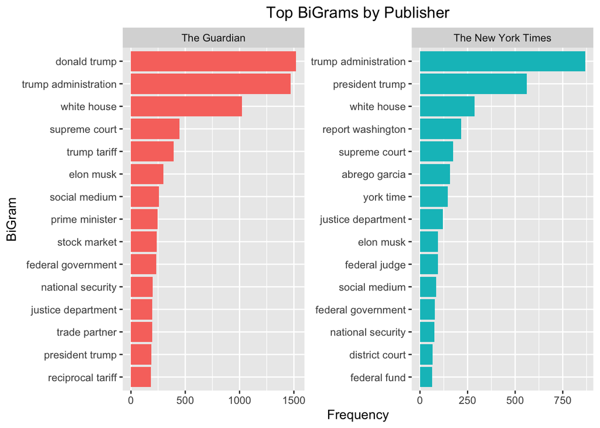

```r
# Tokenization and Normalization (bigrams)
tokenisation_standardisation_bigrams <- function(df) {
  df <- df %>%
    unnest_tokens(bigram, cleaned_body, token = "ngrams", n = 2) %>%
    separate(bigram, into = c("word1", "word2"), sep = " ") %>%
    mutate(
      word1 = lemmatize_words(word1),
      word2 = lemmatize_words(word2)
    ) %>% # Reducing the words to its base form
    filter(
      str_length(word1) >= 4,
      str_length(word2) >= 4,
      str_detect(word1, "^[a-z]+$"),
      str_detect(word2, "^[a-z]+$")
    ) %>% # Removing words with length < 4 and only words with alphabets
    anti_join(stop_words, by = c("word1" = "word")) %>% # Handling stopwords
    anti_join(stop_words, by = c("word2" = "word")) %>% # Handling stopwords
    unite("bigram", word1, word2, sep = " ")
}

# Tokenization and Standardisation of the words (bigrams)
guardian_data_tokenized_bigrams <- tokenisation_standardisation_bigrams(combined_news)

# Topic Coverage Analysis based on Bi-grams
top_bigrams <- guardian_data_tokenized_bigrams %>%
  count(publisher, bigram, sort = TRUE) %>%
  group_by(publisher) %>%
  slice_max(n, n = 15) %>%
  ungroup()

# Visualization of top words from the news articles
top_bigrams %>%
  ggplot(aes(x = reorder_within(bigram, n, publisher), y = n, fill = publisher)) +
  geom_col(show.legend = FALSE) +
  facet_wrap(~publisher, scales = "free") +
  scale_x_reordered() +
  coord_flip() +
  labs(title = "Top BiGrams by Publisher",
       x = "BiGram", y = "Frequency") +
  theme(
    plot.title = element_text(hjust = 0.5)
  )
```

The bigram analysis shows both publishers frequently mention “trump administration”, “white house”, and “supreme court”, highlighting shared political focus. The Guardian leans toward international and economic themes with terms like “trump tariff” and “prime minister”. In contrast, The New York Times emphasizes institutional and regional references like “report washington” and “district court”.

### TF-IDF Analysis

TF-IDF identifies words that are uniquely important to each publisher by weighing how frequently a term appears in one set of articles relative to its frequency across all articles.

```r
# Loading required libraries
library(spacyr)
# spacy_initialize(model = "en_core_web_sm")

# parse full article bodies
parsed_articles <- spacy_parse(combined_news$cleaned_body, pos = TRUE, lemma = FALSE)
```

```
## successfully initialized (spaCy Version: 3.8.5, language model: en_core_web_sm)
```

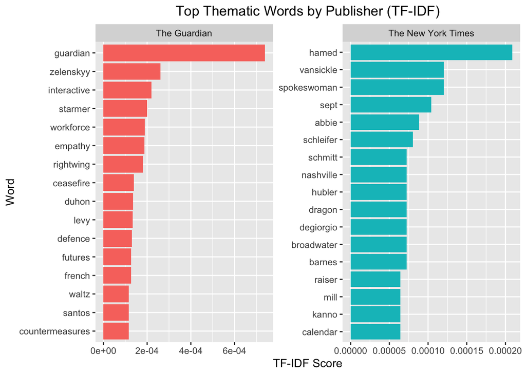

```r
parsed_articles <- parsed_articles %>%
  mutate(doc_id = str_extract_all(doc_id, "[:digit:]+")) %>%
  unnest(cols = c(doc_id)) %>%
  mutate(doc_id = as.numeric(doc_id))

# join back publisher info
parsed_articles <- parsed_articles %>% mutate(publisher = combined_news$publisher[doc_id])

# Determining the meaningful words
meaningful_words <- parsed_articles %>%
  filter(pos %in% c("NOUN", "VERB", "ADJ", "ADV")) %>%
  filter(str_length(token) >= 4, str_detect(token, "^[a-z]+$")) %>%
  anti_join(stop_words, by = c("token" = "word")) %>%
  count(publisher, token, sort = TRUE)

word_tfidf <- meaningful_words %>%
  bind_tf_idf(term = token, document = publisher, n = n) %>%
  arrange(desc(tf_idf))

top_terms <- word_tfidf %>%
  group_by(publisher) %>%
  slice_max(tf_idf, n = 15) %>%
  ungroup()

# Plotting TF-IDF top 15 words unique to each publisher
ggplot(top_terms, aes(x = reorder_within(token, tf_idf, publisher),
                      y = tf_idf, fill = publisher)) +
      geom_col(show.legend = FALSE) +
      facet_wrap(~ publisher, scales = "free") +
      coord_flip() +
      scale_x_reordered() +
      labs(title = "Top Thematic Words by Publisher (TF-IDF)",
           x = "Word", y = "TF-IDF Score") +
      theme(
        plot.title = element_text(hjust = 0.5)
      )
```

## Sentiment Analysis

To understand how each publisher conveys tone and emotion in their coverage, we conducted sentiment analysis using two widely accepted lexicons: Bing (positive/negative polarity) and NRC (eight basic emotions and sentiment). This allowed us to capture both overall sentiment direction and emotional nuance.

- Lexicon-Based Analysis: We applied the Bing lexicon to classify words as positive or negative and the NRC lexicon to capture a broader set of emotions like anger, trust, and fear.
- Overall Sentiment Scores: We computed net sentiment (positive minus negative words) to compare the general tone of coverage across publishers.
- Day-wise Sentiment Trends: We tracked how sentiment fluctuates over time by aggregating scores at the daily or weekly level.
- Emotion Facet Charts: Using NRC categories, we visualized the intensity of different emotions (e.g., trust, anger) by publisher to better understand how stories are emotionally framed.

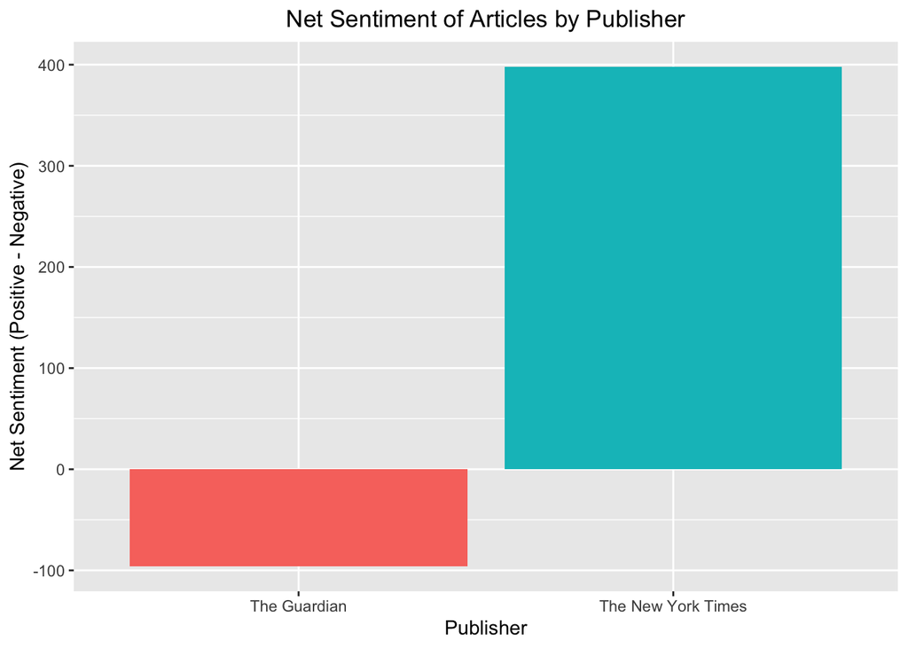

```r
# Downloading sentiment lexicons
sentiment_words_bing <- get_sentiments("bing") # for positive-negative sentiment
sentiment_words_nrc <- get_sentiments("nrc") # for emotion tracking

# Measuring sentiment of the articles (based on bing lexicon)
article_sentiment <- combined_news %>%
  unnest_tokens(word, cleaned_body) %>%
  inner_join(sentiment_words_bing, by = "word") %>%
  count(publisher, sentiment) %>%
  pivot_wider(names_from = sentiment, values_from = n, values_fill = 0) %>%
  mutate(net_sentiment = positive - negative)

ggplot(article_sentiment, aes(x = publisher, y = net_sentiment, fill = publisher)) +
  geom_col(show.legend = FALSE) +
  labs(title = "Net Sentiment of Articles by Publisher",
       y = "Net Sentiment (Positive - Negative)", x = "Publisher") +
  theme(
        plot.title = element_text(hjust = 0.5)
      )
```

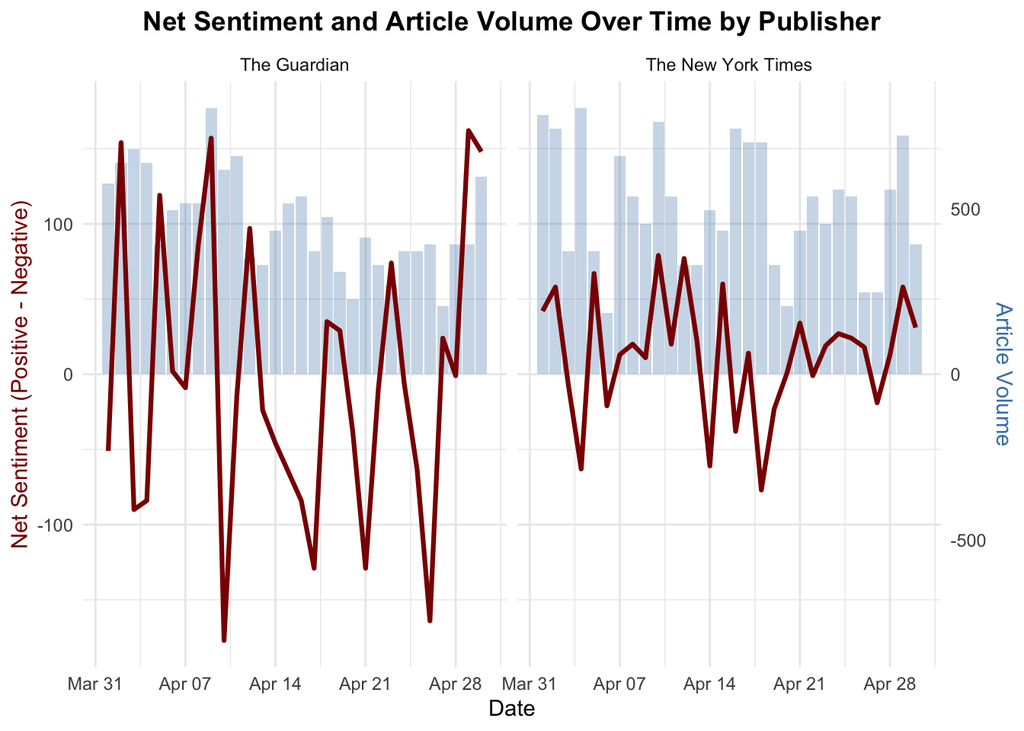

```r
# Measuring the sentiment of articles by day
sentiment_by_day <- combined_news %>%
  unnest_tokens(word, cleaned_body) %>%
  inner_join(sentiment_words_bing, by = "word") %>%
  count(pub_date, publisher, sentiment) %>%
  pivot_wider(names_from = sentiment, values_from = n, values_fill = 0) %>%
  mutate(net_sentiment = positive - negative)

# Plot of the Sentiment of The Gaurdian Articles by Day (also volume of articles)
article_counts <- combined_news %>% count(pub_date, publisher, name = "article_count") # Measuring counts of articles
sentiment_by_day <- sentiment_by_day %>% left_join(article_counts, by = c("pub_date", "publisher"))

scale_factor <- max(abs(sentiment_by_day$net_sentiment), na.rm = TRUE) / max(sentiment_by_day$article_count, na.rm = TRUE)
sentiment_by_day <- sentiment_by_day %>% mutate(scaled_count = article_count * scale_factor)

# Plot with facets for each publisher
ggplot(sentiment_by_day, aes(x = pub_date)) +
  geom_col(aes(y = scaled_count), fill = "steelblue", alpha = 0.3) +  # article volume
  geom_line(aes(y = net_sentiment), color = "darkred", linewidth = 1.1) +  # net sentiment
  scale_y_continuous(
    name = "Net Sentiment (Positive - Negative)",
    sec.axis = sec_axis(~ . * scale_factor, name = "Article Volume")
  ) +
  facet_wrap(~ publisher, scales = "free_x") +
  labs(
    title = "Net Sentiment and Article Volume Over Time by Publisher",
    x = "Date"
  ) +
  theme_minimal() +
  theme(
    plot.title = element_text(hjust = 0.5, face = "bold"),
    axis.title.y.left = element_text(color = "darkred"),
    axis.title.y.right = element_text(color = "steelblue")
  )
```

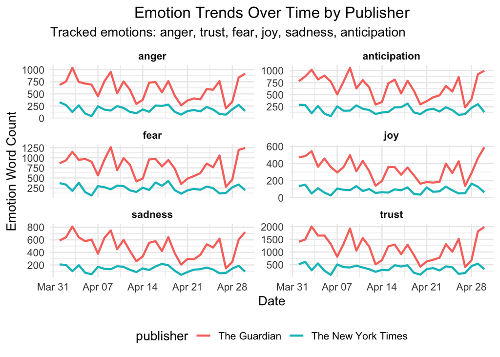

```r
# Tracking emotions per day
emotion_by_day <- combined_news %>%
  unnest_tokens(word, cleaned_body) %>%
  inner_join(sentiment_words_nrc, by = "word", relationship = "many-to-many") %>%
  count(pub_date, publisher, sentiment)  # `sentiment` includes joy, anger, fear, etc.

# Choose emotions to track
selected_emotions <- c("anger", "trust", "fear", "joy", "sadness", "anticipation")

# Plot of the Emotions of The Gaurdian Articles by day
emotion_by_day %>%
  filter(sentiment %in% selected_emotions) %>%
  ggplot(aes(x = pub_date, y = n, color = publisher)) +
  geom_line(linewidth = 1) +
  facet_wrap(~ sentiment, scales = "free_y", ncol = 2) +
  labs(
    title = "Emotion Trends Over Time by Publisher",
    subtitle = paste("Tracked emotions:", paste(selected_emotions, collapse = ", ")),
    x = "Date",
    y = "Emotion Word Count"
  ) +
  theme_minimal(base_size = 13) +
  theme(
    strip.text = element_text(face = "bold"),
    legend.position = "bottom",
    plot.title = element_text(hjust = 0.5)
  )
```

- Across all six emotions (anger, fear, sadness, anticipation, trust, and joy), The Guardian consistently uses more emotionally charged language than The New York Times, indicating a higher emotional tone in its coverage.
- Particularly for fear, sadness, and anger, The Guardian shows sharp peaks and sustained higher word counts, suggesting it often covers topics with more emotionally intense framing.
- Anticipation and trust also appear more frequently in The Guardian, possibly indicating forward-looking or mobilizing language.
- The New York Times maintains a more neutral emotional baseline throughout, with much lower word counts and fewer fluctuations across all emotions.

## Geography Analysis

To complement our text based analysis, we explored the geographical spread of news coverage across the United States. Using Named Entity Recognition (NER), we extracted mentions of U.S. cities and states from article bodies published by The Guardian and The New York Times. These location references were then mapped to their respective states and aggregated weekly to assess how different regions received coverage over time. This analysis helps uncover regional focus or disparities in reporting, and provides spatial insight into the narrative emphasis of each publisher’s national news section.

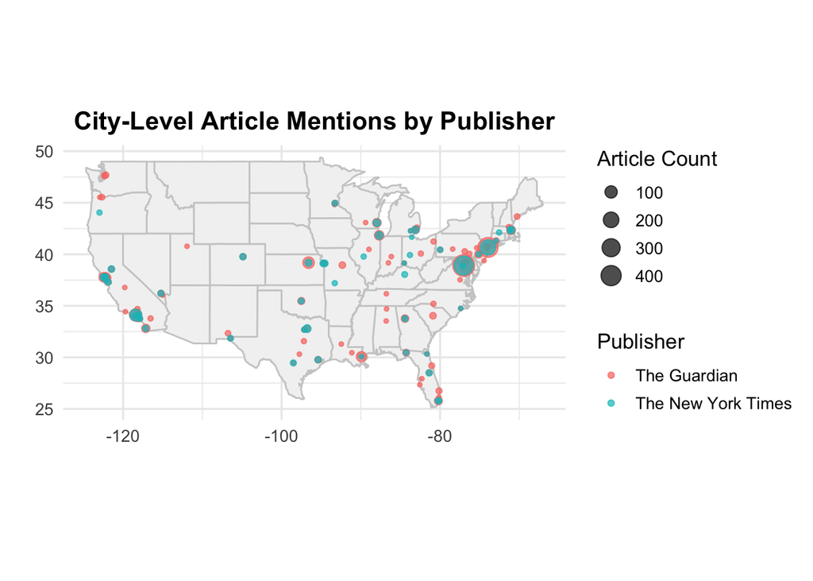

```r
# Loading required libraries
library(purrr)
library(maps)
library(usdata)
library(gganimate)
library(viridis)
library(gifski)

# Run NLP pipeline on all article text
parsed_locations <- spacy_extract_entity(
  combined_news$cleaned_body,
  entity_type = "GPE"
)

# Filtering for entities named as "GPE" (Geo-Political Entity ==> Countries, States, details)
parsed_locations_gpe <- parsed_locations %>% filter(ent_type == "GPE")

parsed_locations_gpe <- parsed_locations_gpe %>%   mutate(text = tolower(text))

parsed_locations_gpe <- parsed_locations_gpe %>%
  mutate(doc_id = str_extract(doc_id, "\\d+")) %>%
  mutate(doc_id = as.numeric(doc_id)) %>%
  left_join(
    combined_news %>%
      mutate(doc_id = row_number()) %>%
      select(doc_id, pub_date, publisher),
    by = "doc_id"
  )

data("us.cities", package = "maps")

us_cities_clean <- us.cities %>%
  mutate(city_clean = tolower(name)) %>%
  mutate(
    parts = str_split(city_clean, "\\s+"),
    state = map_chr(parts, ~ tail(.x, 1)),  # last word as state abbreviation
    city = map_chr(parts, ~ paste(head(.x, -1), collapse = " "))
  ) %>%
  select(city, state, lat, long)

city_matches <- parsed_locations_gpe %>%
  inner_join(us_cities_clean, by = c("text" = "city"), relationship = "many-to-many")


# Aggregate article counts by city and state
city_summary <- city_matches %>%
  count(publisher, text, state, lat, long, name = "article_count")

# Aggregate counts at state level (if needed later)
state_summary <- city_matches %>%
  count(publisher, state, name = "article_count")

# Load US state boundaries
us_states <- map_data("state")

ggplot() +
  geom_polygon(
    data = us_states,
    aes(x = long, y = lat, group = group),
    fill = "gray95", color = "gray80"
  ) +
  geom_point(
    data = city_summary,
    aes(x = long, y = lat, size = article_count, color = publisher),
    alpha = 0.7
  ) +
  coord_fixed(1.3) +
  labs(
    title = "City-Level Article Mentions by Publisher",
    x = "", y = "",
    size = "Article Count",
    color = "Publisher"
  ) +
  theme_minimal(base_size = 13) +
  theme(
    plot.title = element_text(hjust = 0.5, face = "bold"),
    legend.position = "right"
  )
```

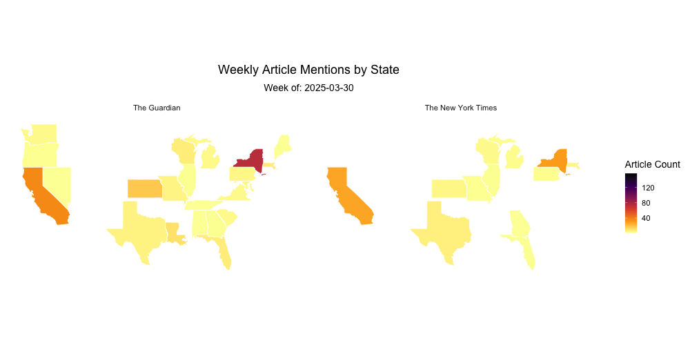

Animated Map

```r
state_summary <- state_summary %>%
  mutate(region = tolower(abbr2state(state)))  # converts "TX" → "texas"

# Prepare state-wise weekly counts by publisher
state_weekly <- city_matches %>%
  mutate(week = floor_date(pub_date, unit = "week")) %>%
  count(publisher, state, week, name = "article_count") %>%
  mutate(region = tolower(abbr2state(state)))  # convert state abbreviations to lowercase state names

# Join with US map data
us_states <- map_data("state")
map_data_weekly <- us_states %>%
  left_join(state_weekly, by = "region", relationship = "many-to-many")

map_data_weekly <- map_data_weekly %>%
  filter(!is.na(week))
# Animated choropleth plot
p_anim <- ggplot(map_data_weekly, aes(x = long, y = lat, group = group)) +
  geom_polygon(aes(fill = article_count), color = "white", linewidth = 0.3) +
  coord_fixed(1.3) +
  scale_fill_viridis_c(option = "inferno", direction = -1, na.value = "grey90") +
  facet_wrap(~ publisher) +
  theme_minimal(base_size = 14) +
  theme(
    axis.text = element_blank(),
    axis.title = element_blank(),
    panel.grid = element_blank(),
    plot.title = element_text(size = 18, face = "bold", hjust = 0.5),
    plot.subtitle = element_text(size = 14, hjust = 0.5, margin = margin(b = 10)),
    legend.position = "right"
  ) +
  transition_time(week) +
  labs(
    title = "Weekly Article Mentions by State",
    subtitle = "Week of: {frame_time}",
    fill = "Article Count"
  ) +
  ease_aes("linear")

# Export as animated GIF
animate(p_anim,
        width = 1000,
        height = 500,
        duration = 10,
        fps = 5,
        renderer = gifski_renderer("animated_map.gif"))
```

# Conclusion